# Overview

Welcome to my exploration of the data job market, with a particular focus on roles in data analysis. This project aims to provide insights to navigate and comprehend the job market more effectively. It delves into identifying the highest-paying and most sought-after skills to optimize job opportunities for data analysts.

The dataset used in this analysis serves as the bedrock of my investigation, encompassing comprehensive details on job titles, salaries, geographic locations, and critical skills. Through Python scripts, I address pivotal inquiries such as the skills most in demand, salary dynamics, and the correlation between skill demand and salary levels within the field of data analytics.

# Questions

Below are the questions I want to answer in my project:

- 1. What are the skills most in demand for the top 3 most popular data roles?
- 1. How are in-demand skills trending for Data Analysts?
- 1. How well do jobs and skills pay for Data Analysts?
- 1. What are the optimal skills for data analysts to learn? (High Demand AND High Paying)

# Tools I used

### For my deep dive into the data analyst job market, I harnessed the power of several key tools:

- Python: The backbone of my analysis, allowing me to analyze the data and find critical insights.I also used the following Python libraries:
- Pandas Library: This was used to analyze the data.
- Matplotlib Library: I visualized the data.
- Seaborn Library: Helped me create more advanced visuals.

## Import and Data Cleanup

```python
# Importing libraries
import ast
import pandas as pd
import seaborn as sns
import matplotlib.pyplot as plt
```

```python
# Loading Data
df = pd.read_csv('/Users/wiltonngo/Downloads/data_jobs.csv')
df.head()
```

|  | job_title_short | job_title | job_location | job_via | job_schedule_type | job_work_from_home | search_location | job_posted_date | job_no_degree_mention | job_health_insurance | job_country | salary_rate | salary_year_avg | salary_hour_avg | company_name | job_skills | job_type_skills |
| --- | --- | --- | --- | --- | --- | --- | --- | --- | --- | --- | --- | --- | --- | --- | --- | --- | --- |
| 0 | Senior Data Engineer | Senior Clinical Data Engineer / Principal Clin... | Watertown, CT | via Work Nearby | Full-time | False | Texas, United States | 2023-06-16 13:44:15 | False | False | United States | NaN | NaN | NaN | Boehringer Ingelheim | NaN | NaN |
| 1 | Data Analyst | Data Analyst | Guadalajara, Jalisco, Mexico | via BeBee México | Full-time | False | Mexico | 2023-01-14 13:18:07 | False | False | Mexico | NaN | NaN | NaN | Hewlett Packard Enterprise | ['r', 'python', 'sql', 'nosql', 'power bi', 't... | {'analyst_tools': ['power bi', 'tableau'], 'pr... |
| 2 | Data Engineer | Data Engineer/Scientist/Analyst, Mid or Senior... | Berlin, Germany | via LinkedIn | Full-time | False | Germany | 2023-10-10 13:14:55 | False | False | Germany | NaN | NaN | NaN | ALPHA Augmented Services | ['python', 'sql', 'c#', 'azure', 'airflow', 'd... | {'analyst_tools': ['dax'], 'cloud': ['azure'],... |
| 3 | Data Engineer | LEAD ENGINEER - PRINCIPAL ANALYST - PRINCIPAL ... | San Antonio, TX | via Diversity.com | Full-time | False | Texas, United States | 2023-07-04 13:01:41 | True | False | United States | NaN | NaN | NaN | Southwest Research Institute | ['python', 'c++', 'java', 'matlab', 'aws', 'te... | {'cloud': ['aws'], 'libraries': ['tensorflow',... |
| 4 | Data Engineer | Data Engineer- Sr Jobs | Washington, DC | via Clearance Jobs | Full-time | False | Sudan | 2023-08-07 14:29:36 | False | False | Sudan | NaN | NaN | NaN | Kristina Daniel | ['bash', 'python', 'oracle', 'aws', 'ansible',... | {'cloud': ['oracle', 'aws'], 'other': ['ansibl... |

```python
# Data Cleanup
df['job_posted_date'] = pd.to_datetime(df['job_posted_date'])
df['job_skills'] = df['job_skills'].apply(lambda x: ast.literal_eval(x) if pd.notna(x) else x)
```

# Filter for US Data Analyst Roles

```python
df_DA_US = df[(df['job_country'] == 'United States') & (df['job_title_short'] == 'Data Analyst')]
```

# Locations to Explore:

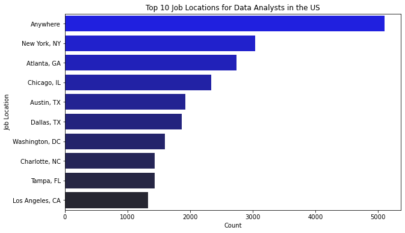

```python
# Step 1: Calculate the value counts for 'job_location' and take the top 10
df_plot = df_DA_US['job_location'].value_counts().head(10).reset_index()
df_plot.columns = ['job_location', 'count']  # Rename columns for clarity

# Step 2: Create the bar plot using seaborn
plt.figure(figsize=(10, 6))  # Adjust the figure size if needed
sns.barplot(data=df_plot, x='count', y='job_location', palette='dark:b_r')

# Step 3: Customize labels and title
plt.xlabel('Count')  # Label for x-axis
plt.ylabel('Job Location')  # Label for y-axis
plt.title('Top 10 Job Locations for Data Analysts in the US')  # Plot title


# Step 4: Show the plot
plt.show()
```

# Job Opportunties

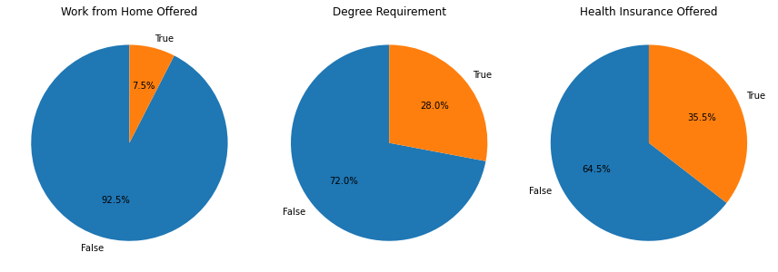

```python
dict_column = {
    'job_work_from_home': 'Work from Home Offered',
    'job_no_degree_mention': 'Degree Requirement',
    'job_health_insurance': 'Health Insurance Offered'
}

fig, ax = plt.subplots(1, 3, figsize=(12, 5))  # Correcting the size setting

for i, (column, title) in enumerate(dict_column.items()):
    counts = df_DA_US[column].value_counts()
    ax[i].pie(counts, labels=counts.index, autopct='%1.1f%%', startangle=90)
    ax[i].set_title(title)

plt.tight_layout()  # Ensures proper spacing between subplots
plt.show()
```

# Companies to Explore:

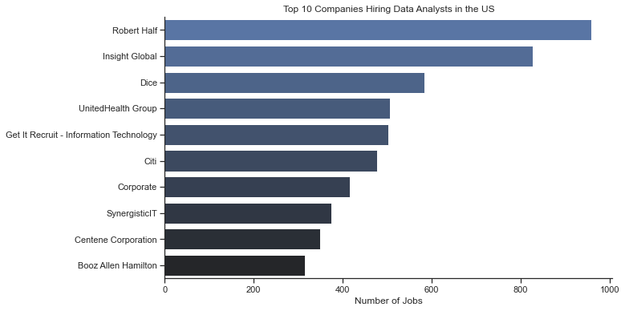

```python
df_plot = df_DA_US['company_name'].value_counts().head(10).to_frame()
df_plot.reset_index(inplace=True)
df_plot.columns = ['company_name', 'count']  # Rename columns for clarity

sns.set_theme(style='ticks')

# Create the bar plot using seaborn
plt.figure(figsize=(10, 6))  # Adjust figure size if needed
sns.barplot(data=df_plot, x='count', y='company_name', palette='dark:b_r')

# Customize plot elements
plt.title('Top 10 Companies Hiring Data Analysts in the US')
plt.xlabel('Number of Jobs')
plt.ylabel('')

# Remove the legend
plt.legend([], [], frameon=False)

# Remove top and right spines
sns.despine()

# Show the plot
plt.show()
```